# Risk Factor Analysis

## Outcome Variable

**Outcome Variable:** ever_swasted

## Predictor Variables

**Intervention Variable:** nhh

**Adjustment Set:**

- arm
- W_mage
- meducyrs
- feducyrs
- W_mhtcm
- W_mwtkg
- W_mbmi
- W_nrooms
- impfloor
- impsan
- safeh20
- delta_W_mage
- delta_meducyrs
- delta_feducyrs
- delta_W_mhtcm
- delta_W_mwtkg
- delta_W_mbmi
- delta_W_nrooms
- delta_impfloor
- delta_impsan
- delta_safeh20

## Stratifying Variables

The analysis was stratified on these variable(s):

- agecat
- studyid
- country

## Data Summary

| agecat | studyid | country | nhh | ever_swasted | n_cell | n |
| --- | --- | --- | --- | --- | --- | --- |
| 0-24 months | IRC | INDIA | 3 or less | 0 | 35 | 410 |
| 0-24 months | IRC | INDIA | 3 or less | 1 | 23 | 410 |
| 0-24 months | IRC | INDIA | 4-5 | 0 | 109 | 410 |
| 0-24 months | IRC | INDIA | 4-5 | 1 | 49 | 410 |
| 0-24 months | IRC | INDIA | 6-7 | 0 | 69 | 410 |
| 0-24 months | IRC | INDIA | 6-7 | 1 | 38 | 410 |
| 0-24 months | IRC | INDIA | 8+ | 0 | 57 | 410 |
| 0-24 months | IRC | INDIA | 8+ | 1 | 30 | 410 |
| 0-24 months | LCNI-5 | MALAWI | 3 or less | 0 | 224 | 817 |
| 0-24 months | LCNI-5 | MALAWI | 3 or less | 1 | 1 | 817 |
| 0-24 months | LCNI-5 | MALAWI | 4-5 | 0 | 334 | 817 |
| 0-24 months | LCNI-5 | MALAWI | 4-5 | 1 | 6 | 817 |
| 0-24 months | LCNI-5 | MALAWI | 6-7 | 0 | 182 | 817 |
| 0-24 months | LCNI-5 | MALAWI | 6-7 | 1 | 0 | 817 |
| 0-24 months | LCNI-5 | MALAWI | 8+ | 0 | 69 | 817 |
| 0-24 months | LCNI-5 | MALAWI | 8+ | 1 | 1 | 817 |
| 0-24 months | NIH-Birth | BANGLADESH | 3 or less | 0 | 95 | 624 |
| 0-24 months | NIH-Birth | BANGLADESH | 3 or less | 1 | 20 | 624 |
| 0-24 months | NIH-Birth | BANGLADESH | 4-5 | 0 | 220 | 624 |
| 0-24 months | NIH-Birth | BANGLADESH | 4-5 | 1 | 43 | 624 |
| 0-24 months | NIH-Birth | BANGLADESH | 6-7 | 0 | 119 | 624 |
| 0-24 months | NIH-Birth | BANGLADESH | 6-7 | 1 | 22 | 624 |
| 0-24 months | NIH-Birth | BANGLADESH | 8+ | 0 | 91 | 624 |
| 0-24 months | NIH-Birth | BANGLADESH | 8+ | 1 | 14 | 624 |
| 0-24 months | NIH-Crypto | BANGLADESH | 3 or less | 0 | 103 | 758 |
| 0-24 months | NIH-Crypto | BANGLADESH | 3 or less | 1 | 11 | 758 |
| 0-24 months | NIH-Crypto | BANGLADESH | 4-5 | 0 | 310 | 758 |
| 0-24 months | NIH-Crypto | BANGLADESH | 4-5 | 1 | 32 | 758 |
| 0-24 months | NIH-Crypto | BANGLADESH | 6-7 | 0 | 164 | 758 |
| 0-24 months | NIH-Crypto | BANGLADESH | 6-7 | 1 | 14 | 758 |

[output cut: 114 more lines]

The following strata were considered:

- agecat: 0-24 months, studyid: IRC, country: INDIA
- agecat: 0-24 months, studyid: LCNI-5, country: MALAWI
- agecat: 0-24 months, studyid: NIH-Birth, country: BANGLADESH
- agecat: 0-24 months, studyid: NIH-Crypto, country: BANGLADESH
- agecat: 0-24 months, studyid: PROVIDE, country: BANGLADESH
- agecat: 0-24 months, studyid: SAS-FoodSuppl, country: INDIA
- agecat: 0-6 months, studyid: IRC, country: INDIA
- agecat: 0-6 months, studyid: LCNI-5, country: MALAWI
- agecat: 0-6 months, studyid: NIH-Birth, country: BANGLADESH
- agecat: 0-6 months, studyid: NIH-Crypto, country: BANGLADESH
- agecat: 0-6 months, studyid: PROVIDE, country: BANGLADESH
- agecat: 0-6 months, studyid: SAS-FoodSuppl, country: INDIA
- agecat: 6-24 months, studyid: IRC, country: INDIA
- agecat: 6-24 months, studyid: LCNI-5, country: MALAWI
- agecat: 6-24 months, studyid: NIH-Birth, country: BANGLADESH
- agecat: 6-24 months, studyid: NIH-Crypto, country: BANGLADESH
- agecat: 6-24 months, studyid: PROVIDE, country: BANGLADESH
- agecat: 6-24 months, studyid: SAS-FoodSuppl, country: INDIA

### Dropped Strata

Some strata were dropped due to rare outcomes:

- agecat: 0-24 months, studyid: LCNI-5, country: MALAWI
- agecat: 0-6 months, studyid: LCNI-5, country: MALAWI
- agecat: 0-6 months, studyid: SAS-FoodSuppl, country: INDIA
- agecat: 6-24 months, studyid: IRC, country: INDIA
- agecat: 6-24 months, studyid: LCNI-5, country: MALAWI
- agecat: 6-24 months, studyid: NIH-Crypto, country: BANGLADESH
- agecat: 6-24 months, studyid: PROVIDE, country: BANGLADESH

## Methods Detail

We’re interested in the causal parameters $E[Y_a]$ for all values of $a \in \mathcal{A}$. These parameters represent the mean outcome if, possibly contrary to fact, we intervened to set all units to have $A=a$. Under the randomization and positivity assumptions, these are identified by the statistical parameters $\psi_a=E_W[E_{Y|A,W}(Y|A=a,W)]$. In addition, we’re interested in the mean of $Y$, $E[Y]$ under no intervention (the observed mean). We will estimate these parameters by using SuperLearner to fit the relevant likelihood factors – $E_{Y|A,W}(Y|A=a,W)$ and $p(A=a|W)$, and then updating our likelihood fit using a joint TMLE.

For unadjusted analyses ($W=\{\}$), initial likelihoods were estimated using Lrnr_glm to estimate the simple $E(Y|A)$ and Lrnr_mean to estimate $p(A)$. For adjusted analyses, a small library containing Lrnr_glmnet, Lrnr_xgboost, and Lrnr_mean was used.

Having estimated these parameters, we will then use the delta method to estimate relative risks and attributable risks relative to a prespecified baseline level of $A$.

# Results Detail

## Results Plots

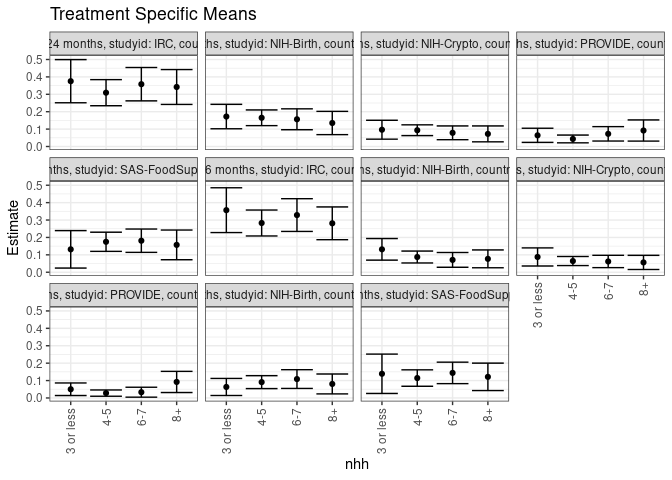

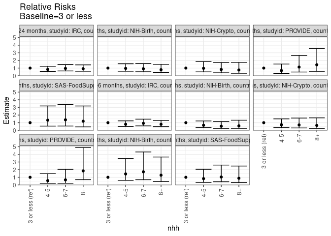

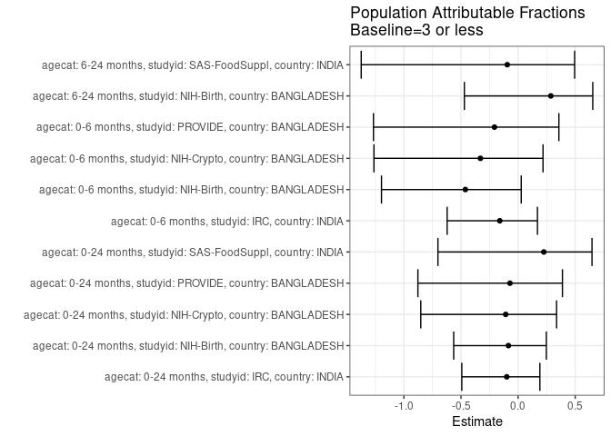

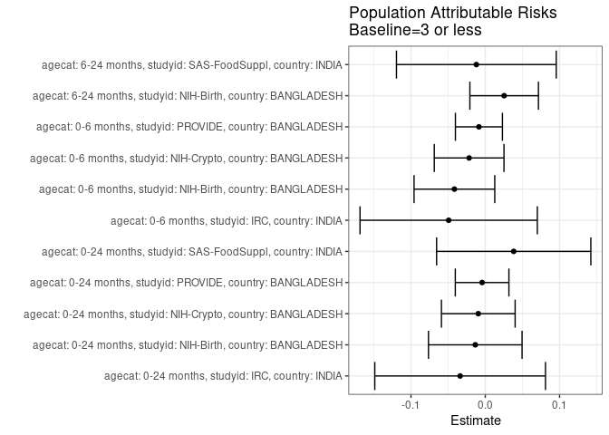

## Results Table

### Parameter: TSM

| agecat | studyid | country | intervention_level | baseline_level | estimate | ci_lower | ci_upper |
| --- | --- | --- | --- | --- | --- | --- | --- |
| 0-24 months | IRC | INDIA | 3 or less | NA | 0.3753250 | 0.2513235 | 0.4993265 |
| 0-24 months | IRC | INDIA | 4-5 | NA | 0.3093362 | 0.2343731 | 0.3842994 |
| 0-24 months | IRC | INDIA | 6-7 | NA | 0.3581211 | 0.2622174 | 0.4540248 |
| 0-24 months | IRC | INDIA | 8+ | NA | 0.3419349 | 0.2417389 | 0.4421309 |
| 0-24 months | NIH-Birth | BANGLADESH | 3 or less | NA | 0.1721280 | 0.1019613 | 0.2422946 |
| 0-24 months | NIH-Birth | BANGLADESH | 4-5 | NA | 0.1650277 | 0.1198988 | 0.2101566 |
| 0-24 months | NIH-Birth | BANGLADESH | 6-7 | NA | 0.1564706 | 0.0963744 | 0.2165667 |
| 0-24 months | NIH-Birth | BANGLADESH | 8+ | NA | 0.1350785 | 0.0682202 | 0.2019369 |
| 0-24 months | NIH-Crypto | BANGLADESH | 3 or less | NA | 0.0964912 | 0.0422546 | 0.1507278 |
| 0-24 months | NIH-Crypto | BANGLADESH | 4-5 | NA | 0.0935673 | 0.0626820 | 0.1244525 |
| 0-24 months | NIH-Crypto | BANGLADESH | 6-7 | NA | 0.0786517 | 0.0390794 | 0.1182239 |
| 0-24 months | NIH-Crypto | BANGLADESH | 8+ | NA | 0.0725806 | 0.0268853 | 0.1182760 |
| 0-24 months | PROVIDE | BANGLADESH | 3 or less | NA | 0.0642857 | 0.0236298 | 0.1049416 |
| 0-24 months | PROVIDE | BANGLADESH | 4-5 | NA | 0.0434783 | 0.0211881 | 0.0657685 |
| 0-24 months | PROVIDE | BANGLADESH | 6-7 | NA | 0.0728477 | 0.0313663 | 0.1143291 |
| 0-24 months | PROVIDE | BANGLADESH | 8+ | NA | 0.0919540 | 0.0311912 | 0.1527169 |
| 0-24 months | SAS-FoodSuppl | INDIA | 3 or less | NA | 0.1315789 | 0.0239734 | 0.2391845 |
| 0-24 months | SAS-FoodSuppl | INDIA | 4-5 | NA | 0.1748634 | 0.1197630 | 0.2299638 |
| 0-24 months | SAS-FoodSuppl | INDIA | 6-7 | NA | 0.1811024 | 0.1140455 | 0.2481592 |
| 0-24 months | SAS-FoodSuppl | INDIA | 8+ | NA | 0.1571429 | 0.0717850 | 0.2425007 |
| 0-6 months | IRC | INDIA | 3 or less | NA | 0.3565998 | 0.2278294 | 0.4853701 |
| 0-6 months | IRC | INDIA | 4-5 | NA | 0.2828269 | 0.2082496 | 0.3574042 |
| 0-6 months | IRC | INDIA | 6-7 | NA | 0.3284181 | 0.2343659 | 0.4224703 |
| 0-6 months | IRC | INDIA | 8+ | NA | 0.2811155 | 0.1870058 | 0.3752252 |
| 0-6 months | NIH-Birth | BANGLADESH | 3 or less | NA | 0.1315789 | 0.0694773 | 0.1936806 |
| 0-6 months | NIH-Birth | BANGLADESH | 4-5 | NA | 0.0874525 | 0.0532834 | 0.1216216 |
| 0-6 months | NIH-Birth | BANGLADESH | 6-7 | NA | 0.0709220 | 0.0285182 | 0.1133258 |
| 0-6 months | NIH-Birth | BANGLADESH | 8+ | NA | 0.0769231 | 0.0256690 | 0.1281771 |
| 0-6 months | NIH-Crypto | BANGLADESH | 3 or less | NA | 0.0877193 | 0.0357563 | 0.1396823 |
| 0-6 months | NIH-Crypto | BANGLADESH | 4-5 | NA | 0.0643275 | 0.0383090 | 0.0903460 |
| 0-6 months | NIH-Crypto | BANGLADESH | 6-7 | NA | 0.0617978 | 0.0264013 | 0.0971942 |
| 0-6 months | NIH-Crypto | BANGLADESH | 8+ | NA | 0.0564516 | 0.0158031 | 0.0971001 |
| 0-6 months | PROVIDE | BANGLADESH | 3 or less | NA | 0.0500000 | 0.0138722 | 0.0861278 |
| 0-6 months | PROVIDE | BANGLADESH | 4-5 | NA | 0.0279503 | 0.0099339 | 0.0459667 |
| 0-6 months | PROVIDE | BANGLADESH | 6-7 | NA | 0.0331126 | 0.0045528 | 0.0616723 |
| 0-6 months | PROVIDE | BANGLADESH | 8+ | NA | 0.0919540 | 0.0311912 | 0.1527169 |
| 6-24 months | NIH-Birth | BANGLADESH | 3 or less | NA | 0.0631579 | 0.0141987 | 0.1121171 |
| 6-24 months | NIH-Birth | BANGLADESH | 4-5 | NA | 0.0909091 | 0.0538026 | 0.1280156 |
| 6-24 months | NIH-Birth | BANGLADESH | 6-7 | NA | 0.1085271 | 0.0548020 | 0.1622523 |
| 6-24 months | NIH-Birth | BANGLADESH | 8+ | NA | 0.0804598 | 0.0232508 | 0.1376688 |
| 6-24 months | SAS-FoodSuppl | INDIA | 3 or less | NA | 0.1388889 | 0.0257789 | 0.2519989 |
| 6-24 months | SAS-FoodSuppl | INDIA | 4-5 | NA | 0.1142857 | 0.0670889 | 0.1614825 |
| 6-24 months | SAS-FoodSuppl | INDIA | 6-7 | NA | 0.1440000 | 0.0823757 | 0.2056243 |
| 6-24 months | SAS-FoodSuppl | INDIA | 8+ | NA | 0.1212121 | 0.0423748 | 0.2000495 |

### Parameter: E(Y)

| agecat | studyid | country | intervention_level | baseline_level | estimate | ci_lower | ci_upper |
| --- | --- | --- | --- | --- | --- | --- | --- |
| 0-24 months | IRC | INDIA | NA | NA | 0.3414634 | 0.2955068 | 0.3874201 |
| 0-24 months | NIH-Birth | BANGLADESH | NA | NA | 0.1586538 | 0.1299648 | 0.1873429 |
| 0-24 months | NIH-Crypto | BANGLADESH | NA | NA | 0.0870712 | 0.0669870 | 0.1071555 |
| 0-24 months | PROVIDE | BANGLADESH | NA | NA | 0.0600000 | 0.0423945 | 0.0776055 |
| 0-24 months | SAS-FoodSuppl | INDIA | NA | NA | 0.1698565 | 0.1338154 | 0.2058975 |
| 0-6 months | IRC | INDIA | NA | NA | 0.3073171 | 0.2626027 | 0.3520314 |
| 0-6 months | NIH-Birth | BANGLADESH | NA | NA | 0.0900322 | 0.0675202 | 0.1125442 |
| 0-6 months | NIH-Crypto | BANGLADESH | NA | NA | 0.0659631 | 0.0482810 | 0.0836451 |
| 0-6 months | PROVIDE | BANGLADESH | NA | NA | 0.0414286 | 0.0266555 | 0.0562017 |
| 6-24 months | NIH-Birth | BANGLADESH | NA | NA | 0.0885609 | 0.0646203 | 0.1125014 |
| 6-24 months | SAS-FoodSuppl | INDIA | NA | NA | 0.1268657 | 0.0942904 | 0.1594410 |

### Parameter: RR

| agecat | studyid | country | intervention_level | baseline_level | estimate | ci_lower | ci_upper |
| --- | --- | --- | --- | --- | --- | --- | --- |
| 0-24 months | IRC | INDIA | 3 or less | 3 or less | 1.0000000 | 1.0000000 | 1.000000 |
| 0-24 months | IRC | INDIA | 4-5 | 3 or less | 0.8241824 | 0.5471888 | 1.241393 |
| 0-24 months | IRC | INDIA | 6-7 | 3 or less | 0.9541627 | 0.6233722 | 1.460486 |
| 0-24 months | IRC | INDIA | 8+ | 3 or less | 0.9110368 | 0.5858119 | 1.416817 |
| 0-24 months | NIH-Birth | BANGLADESH | 3 or less | 3 or less | 1.0000000 | 1.0000000 | 1.000000 |
| 0-24 months | NIH-Birth | BANGLADESH | 4-5 | 3 or less | 0.9587499 | 0.5865603 | 1.567105 |
| 0-24 months | NIH-Birth | BANGLADESH | 6-7 | 3 or less | 0.9090362 | 0.5194548 | 1.590797 |
| 0-24 months | NIH-Birth | BANGLADESH | 8+ | 3 or less | 0.7847564 | 0.4129576 | 1.491297 |
| 0-24 months | NIH-Crypto | BANGLADESH | 3 or less | 3 or less | 1.0000000 | 1.0000000 | 1.000000 |
| 0-24 months | NIH-Crypto | BANGLADESH | 4-5 | 3 or less | 0.9696970 | 0.5052937 | 1.860922 |
| 0-24 months | NIH-Crypto | BANGLADESH | 6-7 | 3 or less | 0.8151175 | 0.3833523 | 1.733175 |
| 0-24 months | NIH-Crypto | BANGLADESH | 8+ | 3 or less | 0.7521994 | 0.3234400 | 1.749332 |
| 0-24 months | PROVIDE | BANGLADESH | 3 or less | 3 or less | 1.0000000 | 1.0000000 | 1.000000 |
| 0-24 months | PROVIDE | BANGLADESH | 4-5 | 3 or less | 0.6763285 | 0.2996322 | 1.526606 |
| 0-24 months | PROVIDE | BANGLADESH | 6-7 | 3 or less | 1.1331862 | 0.4838547 | 2.653919 |
| 0-24 months | PROVIDE | BANGLADESH | 8+ | 3 or less | 1.4303959 | 0.5730891 | 3.570182 |
| 0-24 months | SAS-FoodSuppl | INDIA | 3 or less | 3 or less | 1.0000000 | 1.0000000 | 1.000000 |
| 0-24 months | SAS-FoodSuppl | INDIA | 4-5 | 3 or less | 1.3289617 | 0.5532138 | 3.192508 |
| 0-24 months | SAS-FoodSuppl | INDIA | 6-7 | 3 or less | 1.3763780 | 0.5608709 | 3.377633 |
| 0-24 months | SAS-FoodSuppl | INDIA | 8+ | 3 or less | 1.1942857 | 0.4474406 | 3.187727 |
| 0-6 months | IRC | INDIA | 3 or less | 3 or less | 1.0000000 | 1.0000000 | 1.000000 |
| 0-6 months | IRC | INDIA | 4-5 | 3 or less | 0.7931214 | 0.5070823 | 1.240512 |
| 0-6 months | IRC | INDIA | 6-7 | 3 or less | 0.9209711 | 0.5806921 | 1.460650 |
| 0-6 months | IRC | INDIA | 8+ | 3 or less | 0.7883222 | 0.4817597 | 1.289962 |
| 0-6 months | NIH-Birth | BANGLADESH | 3 or less | 3 or less | 1.0000000 | 1.0000000 | 1.000000 |
| 0-6 months | NIH-Birth | BANGLADESH | 4-5 | 3 or less | 0.6646388 | 0.3601536 | 1.226545 |
| 0-6 months | NIH-Birth | BANGLADESH | 6-7 | 3 or less | 0.5390071 | 0.2516395 | 1.154543 |
| 0-6 months | NIH-Birth | BANGLADESH | 8+ | 3 or less | 0.5846154 | 0.2583787 | 1.322768 |
| 0-6 months | NIH-Crypto | BANGLADESH | 3 or less | 3 or less | 1.0000000 | 1.0000000 | 1.000000 |
| 0-6 months | NIH-Crypto | BANGLADESH | 4-5 | 3 or less | 0.7333333 | 0.3579198 | 1.502509 |
| 0-6 months | NIH-Crypto | BANGLADESH | 6-7 | 3 or less | 0.7044944 | 0.3090409 | 1.605976 |
| 0-6 months | NIH-Crypto | BANGLADESH | 8+ | 3 or less | 0.6435484 | 0.2533022 | 1.635022 |
| 0-6 months | PROVIDE | BANGLADESH | 3 or less | 3 or less | 1.0000000 | 1.0000000 | 1.000000 |
| 0-6 months | PROVIDE | BANGLADESH | 4-5 | 3 or less | 0.5590062 | 0.2122732 | 1.472103 |
| 0-6 months | PROVIDE | BANGLADESH | 6-7 | 3 or less | 0.6622517 | 0.2149657 | 2.040220 |
| 0-6 months | PROVIDE | BANGLADESH | 8+ | 3 or less | 1.8390805 | 0.6908131 | 4.895994 |
| 6-24 months | NIH-Birth | BANGLADESH | 3 or less | 3 or less | 1.0000000 | 1.0000000 | 1.000000 |
| 6-24 months | NIH-Birth | BANGLADESH | 4-5 | 3 or less | 1.4393939 | 0.5993798 | 3.456665 |
| 6-24 months | NIH-Birth | BANGLADESH | 6-7 | 3 or less | 1.7183463 | 0.6849505 | 4.310843 |
| 6-24 months | NIH-Birth | BANGLADESH | 8+ | 3 or less | 1.2739464 | 0.4449600 | 3.647383 |
| 6-24 months | SAS-FoodSuppl | INDIA | 3 or less | 3 or less | 1.0000000 | 1.0000000 | 1.000000 |
| 6-24 months | SAS-FoodSuppl | INDIA | 4-5 | 3 or less | 0.8228571 | 0.3301895 | 2.050622 |
| 6-24 months | SAS-FoodSuppl | INDIA | 6-7 | 3 or less | 1.0368000 | 0.4131907 | 2.601594 |
| 6-24 months | SAS-FoodSuppl | INDIA | 8+ | 3 or less | 0.8727273 | 0.3077792 | 2.474673 |

### Parameter: PAR

| agecat | studyid | country | intervention_level | baseline_level | estimate | ci_lower | ci_upper |
| --- | --- | --- | --- | --- | --- | --- | --- |
| 0-24 months | IRC | INDIA | 3 or less | NA | -0.0338616 | -0.1487383 | 0.0810151 |
| 0-24 months | NIH-Birth | BANGLADESH | 3 or less | NA | -0.0134741 | -0.0764567 | 0.0495085 |
| 0-24 months | NIH-Crypto | BANGLADESH | 3 or less | NA | -0.0094200 | -0.0590201 | 0.0401802 |
| 0-24 months | PROVIDE | BANGLADESH | 3 or less | NA | -0.0042857 | -0.0403647 | 0.0317933 |
| 0-24 months | SAS-FoodSuppl | INDIA | 3 or less | NA | 0.0382775 | -0.0655139 | 0.1420689 |
| 0-6 months | IRC | INDIA | 3 or less | NA | -0.0492827 | -0.1685998 | 0.0700344 |
| 0-6 months | NIH-Birth | BANGLADESH | 3 or less | NA | -0.0415468 | -0.0958582 | 0.0127646 |
| 0-6 months | NIH-Crypto | BANGLADESH | 3 or less | NA | -0.0217562 | -0.0686670 | 0.0251546 |
| 0-6 months | PROVIDE | BANGLADESH | 3 or less | NA | -0.0085714 | -0.0402159 | 0.0230731 |
| 6-24 months | NIH-Birth | BANGLADESH | 3 or less | NA | 0.0254030 | -0.0207476 | 0.0715536 |
| 6-24 months | SAS-FoodSuppl | INDIA | 3 or less | NA | -0.0120232 | -0.1195573 | 0.0955109 |

### Parameter: PAF

| agecat | studyid | country | intervention_level | baseline_level | estimate | ci_lower | ci_upper |
| --- | --- | --- | --- | --- | --- | --- | --- |
| 0-24 months | IRC | INDIA | 3 or less | NA | -0.0991661 | -0.4929998 | 0.1907795 |
| 0-24 months | NIH-Birth | BANGLADESH | 3 or less | NA | -0.0849279 | -0.5638801 | 0.2473409 |
| 0-24 months | NIH-Crypto | BANGLADESH | 3 or less | NA | -0.1081871 | -0.8522003 | 0.3369623 |
| 0-24 months | PROVIDE | BANGLADESH | 3 or less | NA | -0.0714286 | -0.8774746 | 0.3885621 |
| 0-24 months | SAS-FoodSuppl | INDIA | 3 or less | NA | 0.2253521 | -0.7020215 | 0.6474314 |
| 0-6 months | IRC | INDIA | 3 or less | NA | -0.1603644 | -0.6213891 | 0.1695729 |
| 0-6 months | NIH-Birth | BANGLADESH | 3 or less | NA | -0.4614662 | -1.1963663 | 0.0275377 |
| 0-6 months | NIH-Crypto | BANGLADESH | 3 or less | NA | -0.3298246 | -1.2624838 | 0.2183664 |
| 0-6 months | PROVIDE | BANGLADESH | 3 or less | NA | -0.2068966 | -1.2666263 | 0.3573712 |
| 6-24 months | NIH-Birth | BANGLADESH | 3 or less | NA | 0.2868421 | -0.4705892 | 0.6541562 |
| 6-24 months | SAS-FoodSuppl | INDIA | 3 or less | NA | -0.0947712 | -1.3739931 | 0.4951443 |